## Visualizacion

```r
library(tidyverse)
```

#### Scatter Plot

```r
atencion_ciudadano <- read.csv("http://bitsandbricks.github.io/data/gcba_suaci_comunas.csv")
head(atencion_ciudadano, 300)
```

|  | PERIODO | RUBRO | TIPO_PRESTACION | BARRIO | total | COMUNA |
| --- | --- | --- | --- | --- | --- | --- |
| 1 | 201301 | ACERAS | RECLAMO | AGRONOMIA | 6 | 15 |
| 2 | 201301 | ACERAS | RECLAMO | ALMAGRO | 172 | 5 |
| 3 | 201301 | ACERAS | RECLAMO | BALVANERA | 92 | 3 |
| 4 | 201301 | ACERAS | RECLAMO | BARRACAS | 45 | 4 |
| 5 | 201301 | ACERAS | RECLAMO | BELGRANO | 79 | 13 |
| 6 | 201301 | ACERAS | RECLAMO | BOCA | 10 | 4 |
| 7 | 201301 | ACERAS | RECLAMO | BOEDO | 38 | 5 |
| 8 | 201301 | ACERAS | RECLAMO | CABALLITO | 109 | 6 |
| 9 | 201301 | ACERAS | RECLAMO | CHACARITA | 20 | 15 |
| 10 | 201301 | ACERAS | RECLAMO | COGHLAN | 45 | 12 |

[output cut: 290 more lines]

```r
contactos_por_comuna <- atencion_ciudadano %>%
    group_by(COMUNA) %>%
    summarise(miles_contactos = sum(total) / 1000 )

contactos_por_comuna
```

| COMUNA | miles_contactos |
| --- | --- |
| 1 | 684.961 |
| 2 | 48.810 |
| 3 | 71.171 |
| 4 | 94.520 |
| 5 | 77.071 |
| 6 | 82.790 |
| 7 | 95.833 |
| 8 | 61.329 |
| 9 | 91.171 |
| 10 | 113.602 |

[output cut: 6 more lines]

```r
habitantes <- read.csv("http://bitsandbricks.github.io/data/gcba_pob_comunas_17.csv")

habitantes
```

| COMUNA | POBLACION |
| --- | --- |
| 1 | 253271 |
| 2 | 149720 |
| 3 | 192763 |
| 4 | 238809 |
| 5 | 186956 |
| 6 | 184846 |
| 7 | 240607 |
| 8 | 226649 |
| 9 | 170605 |
| 10 | 170282 |

[output cut: 5 more lines]

```r
contactos_por_comuna <- contactos_por_comuna %>% left_join(habitantes)
contactos_por_comuna
```

| COMUNA | miles_contactos | POBLACION |
| --- | --- | --- |
| 1 | 684.961 | 253271 |
| 2 | 48.810 | 149720 |
| 3 | 71.171 | 192763 |
| 4 | 94.520 | 238809 |
| 5 | 77.071 | 186956 |
| 6 | 82.790 | 184846 |
| 7 | 95.833 | 240607 |
| 8 | 61.329 | 226649 |
| 9 | 91.171 | 170605 |
| 10 | 113.602 | 170282 |

[output cut: 6 more lines]

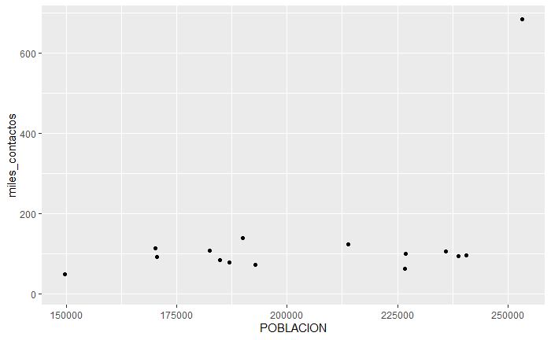

```r
ggplot(contactos_por_comuna) + geom_point(aes(x = POBLACION, y = miles_contactos))
```

Lo que hicimos fue pedirle a ggplot que dibuje un punto por cada fila (representando a cada comuna), con la posición en el eje de las x según su población, y en el eje de las y según la cantidad de contactos registrados. Estas referencias estéticas (aesthetics en inglés) son las que van dentro de la función aes() en geom_point(aes(x = POBLACION, y = miles_contactos)).

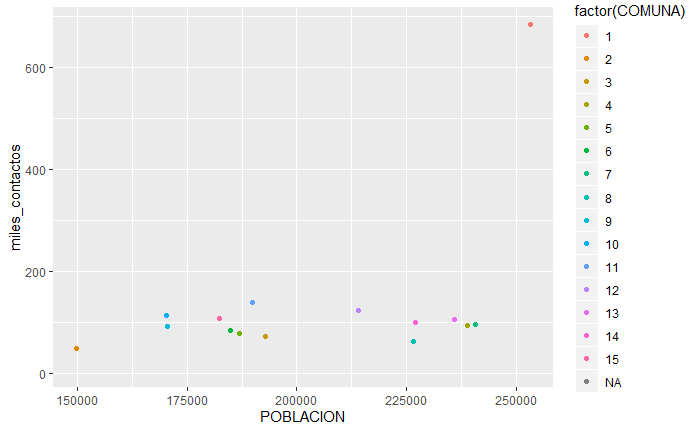

```r
ggplot(contactos_por_comuna) +
    geom_point(aes(x = POBLACION, y = miles_contactos, color = factor(COMUNA)))
```

En ese caso, no es tan fácil discernir cuál es cuál, pero mirando con cuidado descubrimos que la comuna 1 es el outlier, el valor fuera de lo común. Lo que nos pasa aquí es que tenemos demasiadas categorías, con lo cual cada una tiene su propio color pero el rango cromático no alcanza para darle a cada una un tono bien distinto al de las demás.

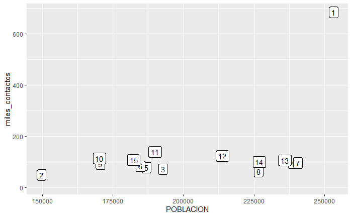

```r
ggplot(contactos_por_comuna) +
    geom_label(aes(x = POBLACION, y = miles_contactos, label = factor(COMUNA)))
```

Para dejar aún más clara la diferencia de reclamos entre comunas, podríamos usar el tamaño (size) de cada punto para representar esa variable, además de su altura en el gráfico.

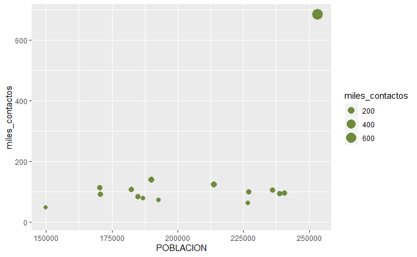

```r
ggplot(contactos_por_comuna) +
    geom_point(aes(x = POBLACION, y = miles_contactos, size = miles_contactos), color = "darkolivegreen4")
```

### Facetado

```r
summary(atencion_ciudadano)
```

```
    PERIODO                         RUBRO        TIPO_PRESTACION
 Min.   :201301   SANEAMIENTO URBANO   : 4589   DENUNCIA :21606
 1st Qu.:201309   TRANSPORTE Y TRANSITO: 4580   QUEJA    : 3914
 Median :201404   ARBOLADO             : 3122   RECLAMO  :21038
 Mean   :201401   ALUMBRADO            : 2918   SOLICITUD: 9662
 3rd Qu.:201503   PAVIMENTO            : 2411   TRAMITE  : 1211
 Max.   :201512   ESPACIO PUBLICO      : 1918
                  (Other)              :37893
         BARRIO          total              COMUNA
 PALERMO    : 2154   Min.   :    1.00   Min.   : 1.000
 BALVANERA  : 1961   1st Qu.:    1.00   1st Qu.: 4.000
 FLORES     : 1959   Median :    4.00   Median : 9.000
 CABALLITO  : 1872   Mean   :   34.85   Mean   : 8.119
 SAN NICOLAS: 1748   3rd Qu.:   16.00   3rd Qu.:12.000
 RECOLETA   : 1729   Max.   :19221.00   Max.   :15.000
 (Other)    :46008                      NA's   :63
```

```r
contactos_por_comuna_y_tipo <- atencion_ciudadano %>%
    group_by(COMUNA, TIPO_PRESTACION) %>%
    summarise(miles_contactos = sum(total) / 1000 ) %>%
    left_join(habitantes)
head(contactos_por_comuna_y_tipo)
```

| COMUNA | TIPO_PRESTACION | miles_contactos | POBLACION |
| --- | --- | --- | --- |
| 1 | DENUNCIA | 22.873 | 253271 |
| 1 | QUEJA | 17.358 | 253271 |
| 1 | RECLAMO | 55.668 | 253271 |
| 1 | SOLICITUD | 20.921 | 253271 |
| 1 | TRAMITE | 568.141 | 253271 |
| 2 | DENUNCIA | 10.152 | 149720 |

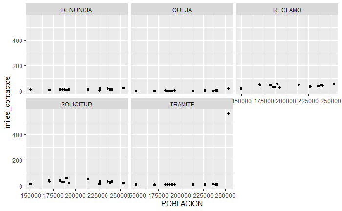

```r
ggplot(contactos_por_comuna_y_tipo) +
    geom_point(aes(x = POBLACION, y = miles_contactos)) +
    facet_wrap(~TIPO_PRESTACION)
```

Producimos un scatterplot igual que antes, y le agregamos una capa adicional con facet_wrap(). La variable a “facetar”, la que recibirá un gráfico por cada una de sus categorías, siempre se escribe a continuación del signo ~; en nuestro caso, queda como ~TIPO_PRESTACION. El simbolillo en cuestión denota lo que en R se denomina una fórmula y ya nos lo cruzaremos de nuevo, pero por ahora no le prestamos más atención.

### Gráficos de barras

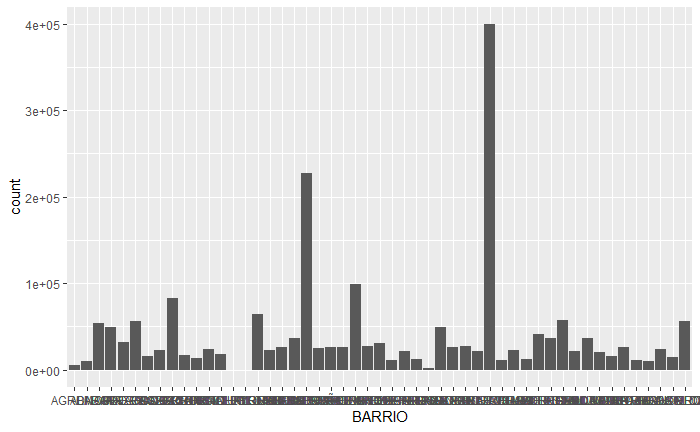

```r
ggplot(atencion_ciudadano) +
geom_bar(aes(x = BARRIO, weight = total))
```

```r
options(scipen = 999)
```

Tenemos dos problemas. El primero es que los valores en el eje de las y son grandes, y R nos quiere hacer un favor expresándolos en notación científica. La notación científica es práctica para ahorrar espacio, pero no queda vien en visualizaciones. Para pedirle que no lo haga mas, usamos `options(scipen = 999)`.

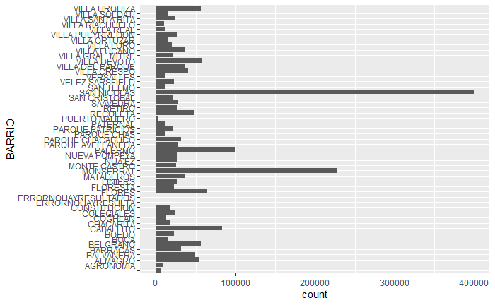

```r
ggplot(atencion_ciudadano) +
    geom_bar(aes(x = BARRIO, weight = total)) +
    coord_flip()
```

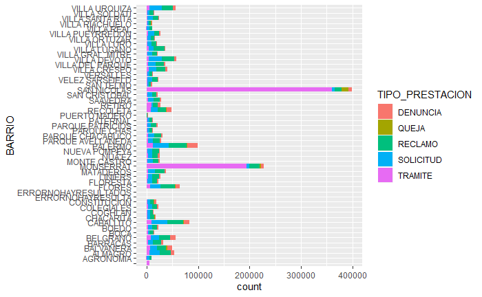

```r
ggplot(atencion_ciudadano) +
    geom_bar(aes(x = BARRIO, weight = total, fill = TIPO_PRESTACION)) +
    coord_flip()
```

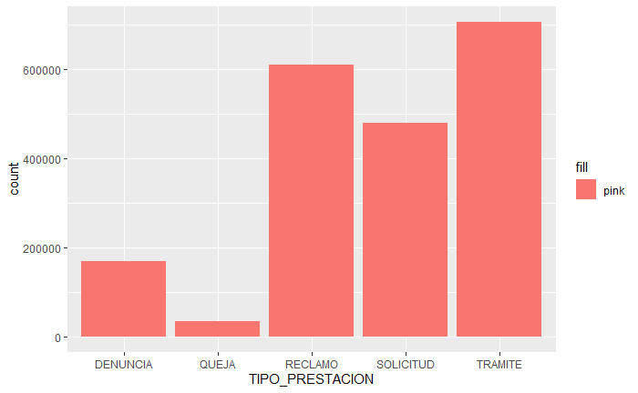

```r
ggplot(atencion_ciudadano) +
    geom_bar(aes(x = TIPO_PRESTACION, weight = total, fill="pink"))
```

¿Y si mostramos el aporte de cada barrio al total global de cada tipo de contacto?

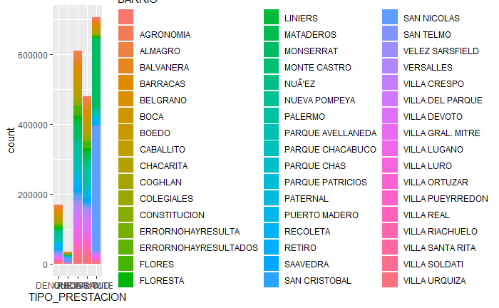

```r
ggplot(atencion_ciudadano) +
    geom_bar(aes(x = TIPO_PRESTACION, weight = total, fill = BARRIO))
```

```r
ggplot(atencion_ciudadano) +
    geom_bar(aes(x = TIPO_PRESTACION, weight = total)) +
    facet_wrap(~BARRIO)
```

[output not shown]

### Histogramas

```r
contactos_por_mes <- atencion_ciudadano %>%
    group_by(PERIODO) %>%
    summarise(gran_total = sum(total))

head(contactos_por_mes)
```

| PERIODO | gran_total |
| --- | --- |
| 201301 | 43826 |
| 201302 | 43666 |
| 201303 | 47405 |
| 201304 | 50768 |
| 201305 | 52761 |
| 201306 | 48344 |

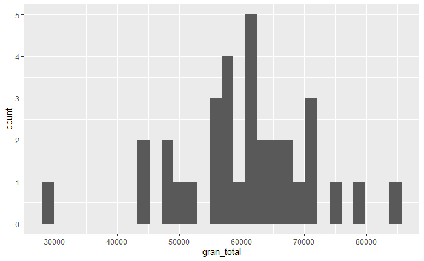

```r
ggplot(contactos_por_mes) +
    geom_histogram(aes(x = gran_total))
```

`geom_histogram()` divide el rango de valores en una cantidad arbitraria de segmentos iguales (“bins” en inglés) y cuenta cuantas observaciones caen en cada uno, cantidad que se representa con la altura de la columna en el eje de las y.

> En nuestro ejemplo, vemos que un mes mes en el que la cantidad de resgitros tiende a agurparse en torno a un valor típico de poco más de 60.000 por mes. En apenas un caso hubo mennos de 40.000 o más de 80.000.

```r
# Hacemos el agrupado y sumario de rigor
contactos_por_mes_y_tipo <- atencion_ciudadano %>%
    group_by(PERIODO, TIPO_PRESTACION) %>%
    summarise(gran_total = sum(total))

head(contactos_por_mes_y_tipo, 300)
```

| PERIODO | TIPO_PRESTACION | gran_total |
| --- | --- | --- |
| 201301 | DENUNCIA | 2740 |
| 201301 | QUEJA | 889 |
| 201301 | RECLAMO | 16011 |
| 201301 | SOLICITUD | 15325 |
| 201301 | TRAMITE | 8861 |
| 201302 | DENUNCIA | 2463 |
| 201302 | QUEJA | 619 |
| 201302 | RECLAMO | 14730 |
| 201302 | SOLICITUD | 14688 |
| 201302 | TRAMITE | 11166 |

[output cut: 155 more lines]

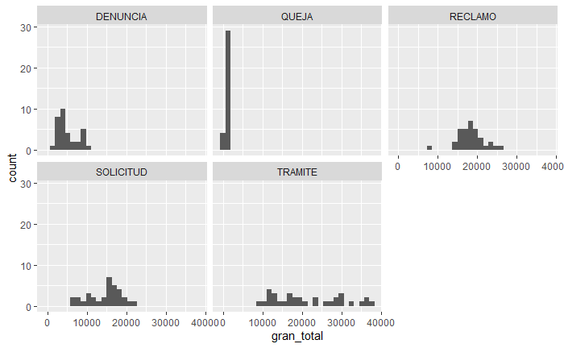

```r
ggplot(contactos_por_mes_y_tipo) +
    geom_histogram(aes(x = gran_total)) +
    facet_wrap(~TIPO_PRESTACION)
```

### Ejemplo deun grafico preparado para compartir

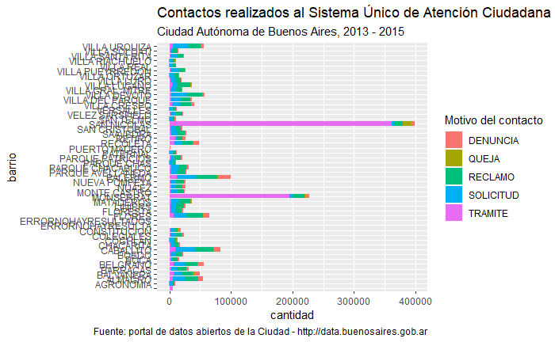

```r
ggplot(atencion_ciudadano) +
    geom_bar(aes(x = BARRIO, weight = total, fill = TIPO_PRESTACION)) +
    coord_flip() +
    labs(title = "Contactos realizados al Sistema Único de Atención Ciudadana",
         subtitle = "Ciudad Autónoma de Buenos Aires, 2013 - 2015",
         caption = "Fuente: portal de datos abiertos de la Ciudad - http://data.buenosaires.gob.ar",
         x = "barrio",
         y = "cantidad",
         fill = "Motivo del contacto")
```